# NSF Terminations under the Trump Administration

2025-06-25

Die folgende Arbeit befasst sich mit den Budget-Kürzungen der Trump-Administration die im April des Jahres 2025 erfolgten. Die Analysen bauen auf den folgenden beiden Datensätzen auf: Zum einen wird der Datensatz “National Science Foundation Grant Terminations under the Trump Administration” aus dem Tidy-Tuesday-Github-Repository verwendet. Zum anderen bezieht sich die Analyse zur Referenz auf Daten aus der öffentlichen API der NSF aus dem Jahr 2024.  
Wir stellen vorab drei Hypothesen auf, die anhand der vorliegenden Daten empirisch geprüft werden sollen.  
1. Die Höhe der Kürzungen hängt signifikant vom jeweiligen Fachbereich ab.  
2. Die Kürzungen hängen in signifikanter Weise von dem Bundesstaat ab, in dem das jeweilige Projekt finanziert wurde. Insbesondere stehen die sogenannten “Blue States” bei den Kürzungen im Vordergrund.  
3. Die Kürzungen hängen in signifikanter Weise von der Formulierung der Projektzusammenfassungen und Projekttitel ab. Hierbei ist die Verwendung von Begriffen, die im Zusamenhang mit “Diversity, Equity, Inclusion” Initiativen stehen, ausschlaggebend.

```r
load_nsf_api_csv <- function(nsf_api_csv_fname)
read_csv(nsf_api_csv_fname) %>%
select(
  grant_number=awd_id,
  project_title=awd_titl_txt,
  abstract = awd_abstract_narration,
  org_name=inst_name,
  org_state=inst_state_code,
  org_city=inst_city_name,
  org_zip=inst_zip_code,
  org_district = st_cong_dist_code,
  org_uei=org_uei_num,
  usaspending_obligated=awd_amount,
  award_type=awd_istr_txt,
  directorate_abbrev=dir_abbr,
  directorate=org_dir_long_name,
  division = org_div_long_name,
  nsf_startdate = awd_eff_date,
  nsf_expected_end_date = awd_exp_date
)
#tuesdata <- tidytuesdayR::tt_load('2025-05-06')
#nsf_terminations <- tuesdata$nsf_terminations
nsf_terminations <- readr::read_csv('https://raw.githubusercontent.com/rfordatascience/tidytuesday/main/data/2025/2025-05-06/nsf_terminations.csv')
nsf_data_2024 <- load_nsf_api_csv("total_grants_2024.csv")
nsf_data_total <- nsf_data_2024
nsf_data_total$terminated <- nsf_data_total$grant_number %in% nsf_terminations$grant_number
```

# Hypothese 1

## Verteilung der Kürzungen nach Fachbereich

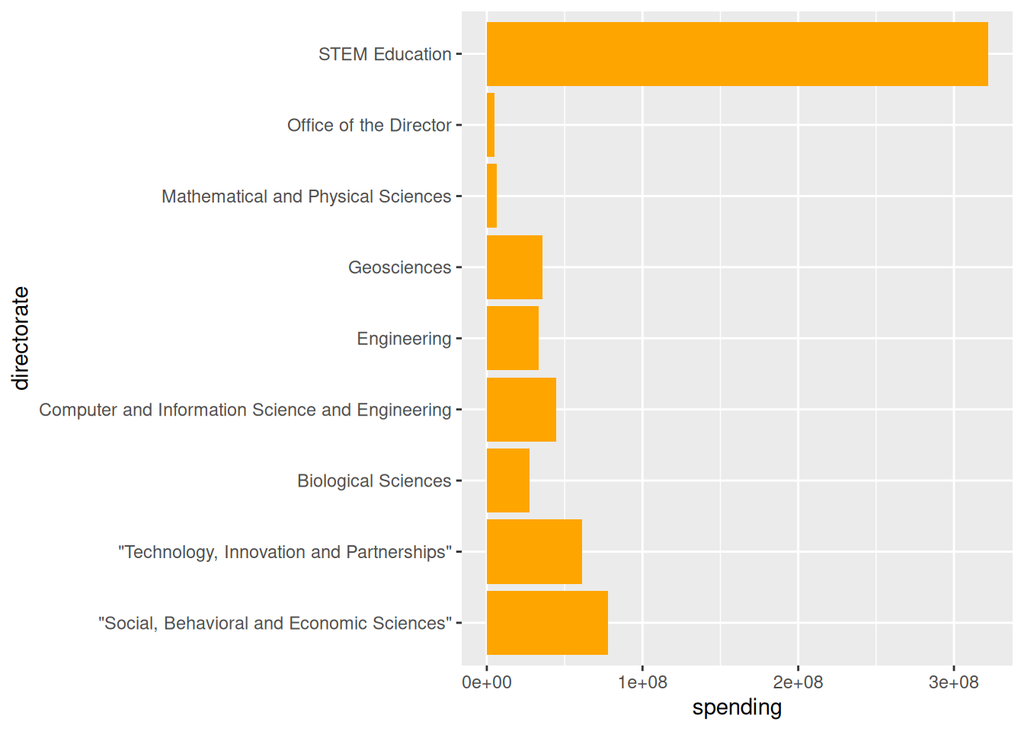

```r
nsf_terminations %>% select(directorate,usaspending_obligated) %>% drop_na() %>% group_by(directorate)  %>% summarize(spending=sum(usaspending_obligated)) %>% ggplot() + coord_flip() + aes(x=directorate,y=spending) + geom_col(fill="orange")
```

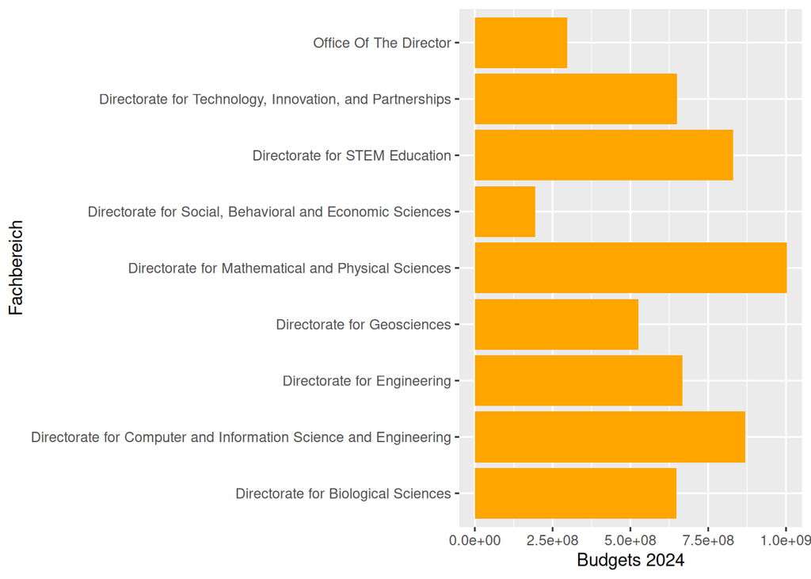

```r
nsf_data_total %>% select(directorate,usaspending_obligated) %>% drop_na() %>% group_by(directorate) %>% summarize(spending=sum(usaspending_obligated)) %>% ggplot() + coord_flip() + aes(x=directorate,y=spending) + labs(x="Fachbereich",y=paste(paste("Budgets",ref_year) )) + geom_col(fill="orange")
```

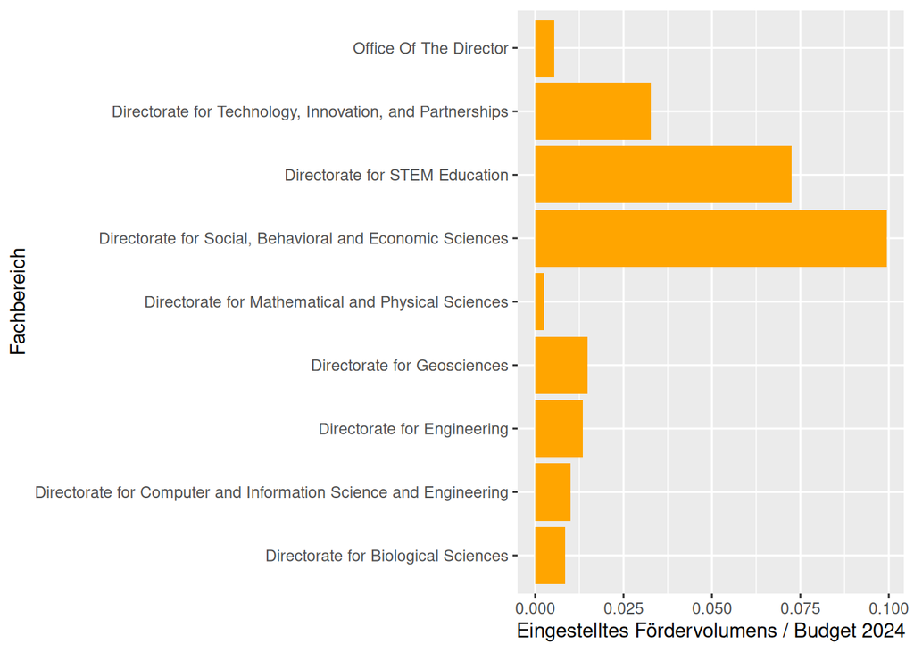

```r
nsf_data_total %>%
  select(terminated,directorate,usaspending_obligated) %>%
  drop_na() %>%
  group_by(directorate) %>%
  summarize(terminated_spending=sum(terminated*usaspending_obligated),spending=sum(usaspending_obligated)) %>%
  mutate(percent_terminated=terminated_spending/spending) %>%
  ggplot() +
  coord_flip() +
  aes(x=directorate,y=percent_terminated)  +
  labs(x="Fachbereich",y=paste(paste("Eingestelltes Fördervolumens / Budget",ref_year) )) +
  geom_col(fill="orange")
```

# Hypothese 2

## Kürzungen des Jährlichen Fördervolumen nach Bundestaaten

Die folgende Grafik zeigt zunächst das gesamte gekürzte Budget. Wie man sehen kann ist das gekürtzte Fördervolumen in den Bundestaaten Californien und New-York besonders hoch. Jedoch gibt es auch andere Bundestaaten wie Texas in denen die Kürzungen des Budget ebenfalls hoch ausgefallen sind was der “Blue-State-Hypothese” wiederspricht.

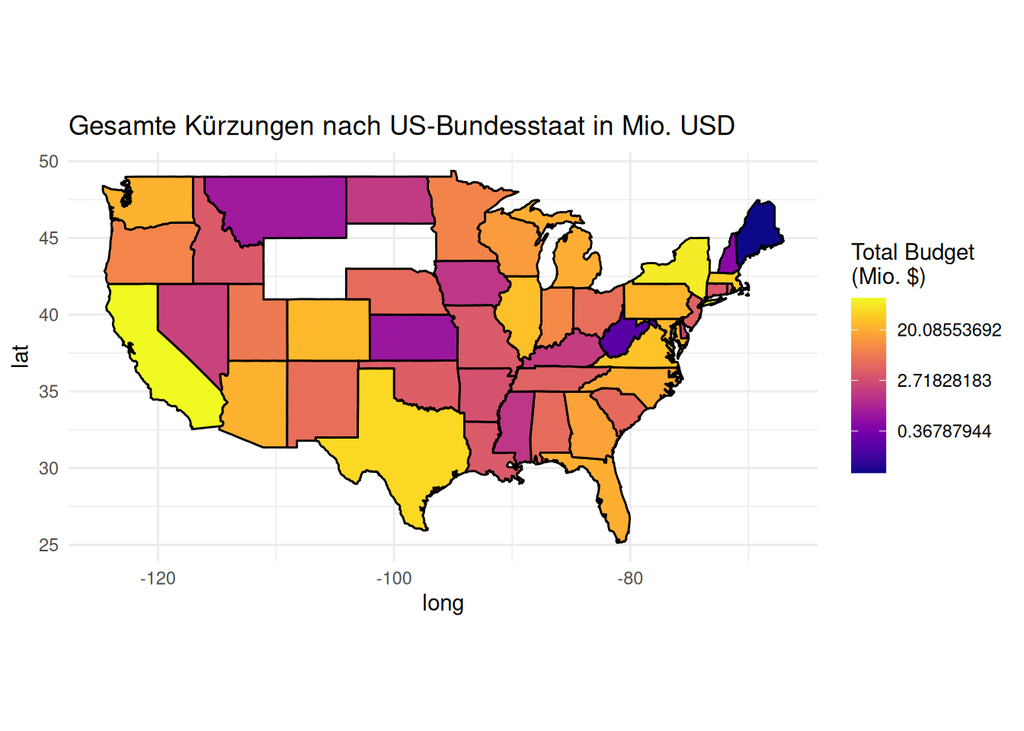

```r
us_states_map <- ggplot2::map_data("state")
state_lookup <- data.frame(org_state=state.abb,region=tolower(state.name))
budget_by_state <- nsf_terminations %>%
  select(state=org_state,budget=usaspending_obligated)%>%
  drop_na() %>%
  group_by(state) %>%
  summarize(budget=sum(budget) / 1e6)
state_lookup <- data.frame(state=state.abb,region=tolower(state.name))
budget_by_state <- budget_by_state %>% left_join(state_lookup, by="state")
us_map_data <- budget_by_state %>% left_join(us_states_map,by="region")

ggplot(us_map_data, aes(long, lat, group = group)) +
  geom_polygon(aes(fill = budget), color = "black") +
  scale_fill_viridis(option = "C", name = "Total Budget\n(Mio. $)",
  na.value = "gray90", trans = "log") +
  coord_fixed(1.3)+
  labs(title = "Gesamte Kürzungen nach US-Bundesstaat in Mio. USD") +
 theme_minimal()
```

Um die Budgets der jeweiligen Bundesstaaten besser verordnen zu können, beziehen wir nun auch die Daten aus dem Jahr 2024 mit ein und betrachten als nächstes das Gesamtbudget, das die NSF im Jahr 2024 vergeben hat.

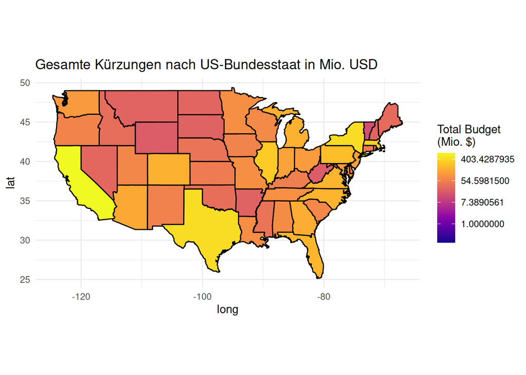

```r
total_budget_by_state <- nsf_data_total %>%
   select(state=org_state,budget=usaspending_obligated)%>%
   drop_na() %>%
   group_by(state) %>%
   summarize(budget=sum(budget) / 1e6)
total_budget_by_state <- total_budget_by_state %>% left_join(state_lookup, by="state")
us_map_data <- total_budget_by_state %>% left_join(us_states_map,by="region")

ggplot(us_map_data, aes(long, lat, group = group)) +
  geom_polygon(aes(fill = budget), color = "black") +
  scale_fill_viridis(option = "C", name = "Total Budget\n(Mio. $)",
  na.value = "gray90", trans = "log") +
  coord_fixed(1.3)+
  labs(title = "Gesamte Kürzungen nach US-Bundesstaat in Mio. USD") +
  theme_minimal()
```

Wie man sehen kann, gibt es eine große Überschneidung zwischen Staaten, in denen die Streichungen besonders hoch ausgefallen sind, und den Staaten mit einem hohen Budget. Daher betrachten wir als nächstes den Anteil des gestrichenen Budgets der Ausschreibungen aus dem Jahr 2024.

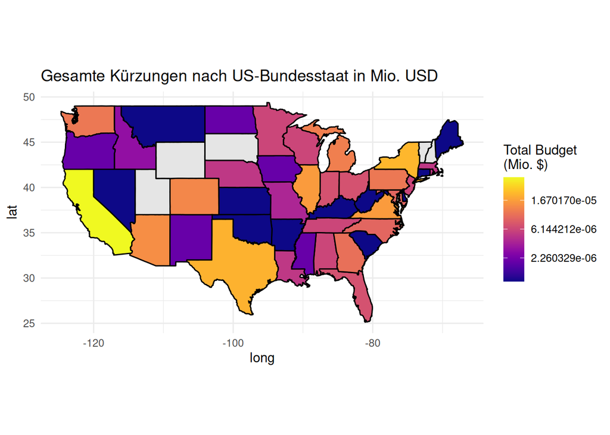

```r
total_budget_by_state <- nsf_data_total %>%
   select(terminated=terminated,state=org_state,budget=usaspending_obligated)%>%
   drop_na() %>%
   group_by(state) %>%
   summarize(budget=sum(budget) / 1e6,
   terminated_budget = sum(budget * terminated) / 1e6)
total_budget_by_state$percent_terminated <- total_budget_by_state$terminated_budget / total_budget_by_state$budget
total_budget_by_state <- total_budget_by_state %>% left_join(state_lookup, by="state")
us_map_data <- total_budget_by_state %>% left_join(us_states_map,by="region")

ggplot(us_map_data, aes(long, lat, group = group)) +
  geom_polygon(aes(fill = percent_terminated), color = "black") +
  scale_fill_viridis(option = "C", name = "Total Budget\n(Mio. $)",
  na.value = "gray90", trans = "log") +
  coord_fixed(1.3)+
  labs(title = "Gesamte Kürzungen nach US-Bundesstaat in Mio. USD") +
  theme_minimal()
```

In den folgenden beiden Graphen lässt sich erkennen, dass ein maßgeblicher Faktor für die Kürzungen sowohl prozentual als auch in absoluten Zahlen das Gesamtbudget des Bundesstaats zu sein scheint. Dies suggeriert, dass die politische Ausrichtung der Bundesstaaten bei den letzten Präsidentschaftswahlen wahrscheinlich nicht der ausschlaggebende Faktor war.

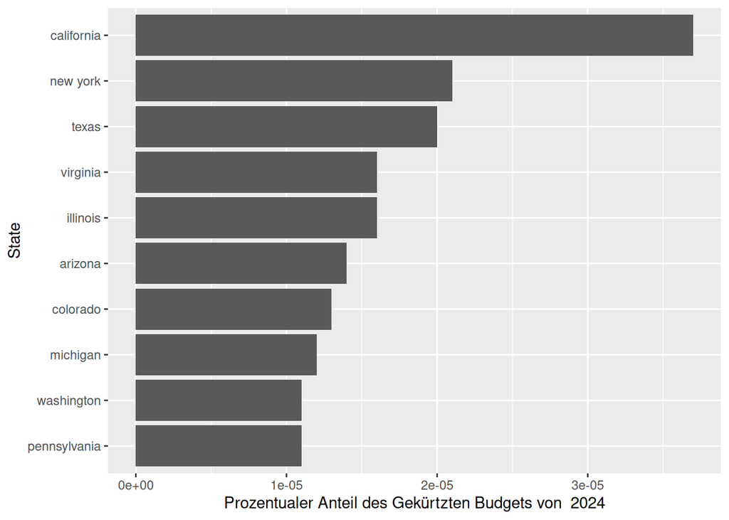

```r
budget_by_state_ref_year <- total_budget_by_state %>%
  select(state=region,budget=budget,terminated_budget=terminated_budget,percent_terminated=percent_terminated)
top_10_by_percent <- budget_by_state_ref_year %>% arrange(-percent_terminated) %>% slice_head(n=10)
top_10_by_percent %>% ggplot() + aes(x=reorder(state,percent_terminated),y=percent_terminated)+ coord_flip()+labs(x="State",y=paste("Prozentualer Anteil des Gekürtzten Budgets von ",ref_year)) + geom_col()
```

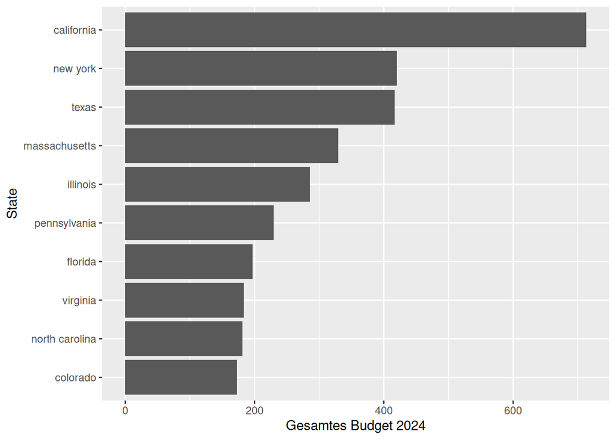

```r
top_10_by_budget <- budget_by_state_ref_year %>% arrange(-budget) %>% slice_head(n=10)
top_10_by_budget %>% ggplot() + aes(x=reorder(state,budget),y=budget) +coord_flip()+ labs(x="State",y=paste("Gesamtes Budget",ref_year)) + geom_col()
```

# Hypothese 3

## Sprachliche Analyse der Projektbeschreibungen

Zunächst betrachten wir die am häufigsten vorkommenden Wörter in den terminierten Fördervergaben.

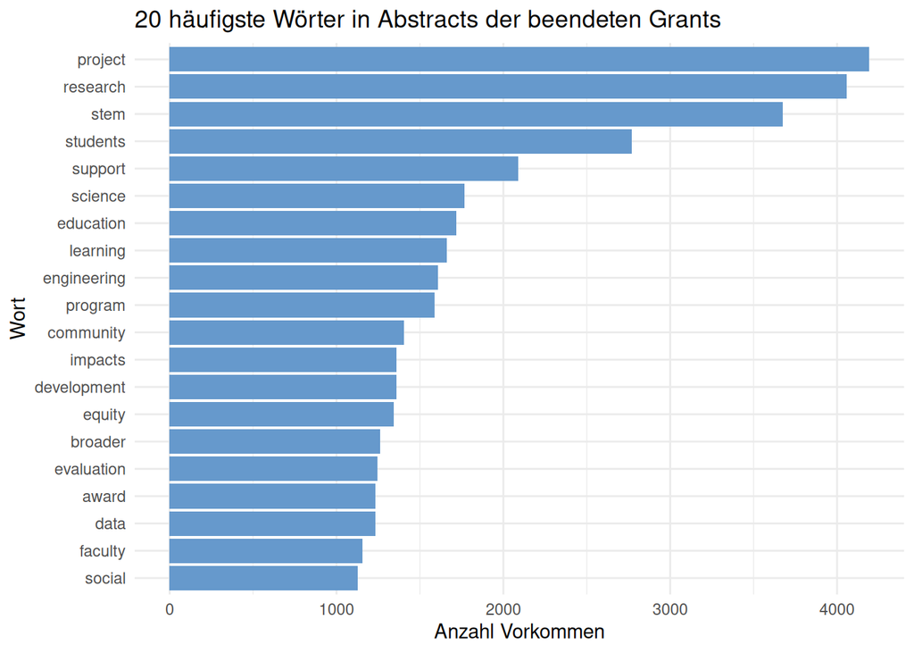

```r
  word_counts <- nsf_terminations %>%
     select(abstract) %>%
     unnest_tokens(word, abstract) %>%      # Text in Wörter aufteilen
     anti_join(stop_words, by = "word")%>%
      count(word,sort=TRUE)# Stoppwörter entfernen (wie „the“,
  word_counts %>%
     top_n(20, n) %>%
     mutate(word = reorder(word, n)) %>%
     ggplot(aes(word, n)) +
     geom_col(fill = "#6699CC") +
     coord_flip() +
     labs(title = "20 häufigste Wörter in Abstracts der beendeten Grants",
          x = "Wort",
          y = "Anzahl Vorkommen") +
     theme_minimal()
```

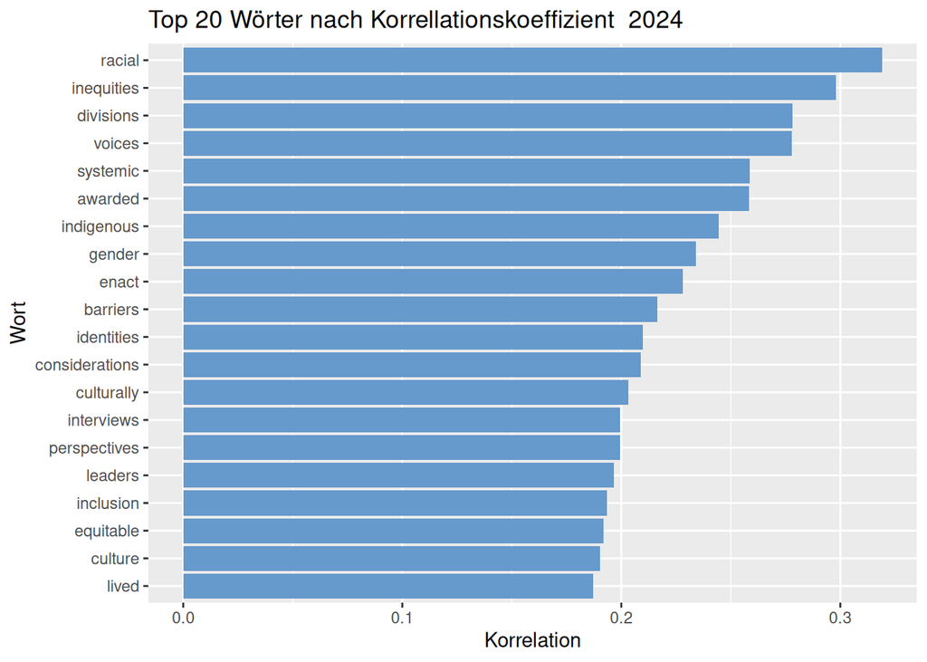

```r
terminated_rows <- nsf_data_total %>% filter(terminated)
non_terminated_rows <- nsf_data_total %>% filter(!terminated)

#For computational reasons we have to restrict the ammount of data so we use all of the terminated and rows and m* the number of rows from the non-terminated projects.
#m has to be adjusted based on the amount of available RAM Larger values of m should lead to more accurate results.
m=10
#Note that the choice of max_df will have to
#be adjusted based on m as the document frequency is not
#normalized relative to the number of non-terminated projects included
max_df=300
train_rows <- rbind(terminated_rows, slice_head(non_terminated_rows,n=m*nrow(terminated_rows)))

corpus <- Corpus(VectorSource(paste(train_rows$project_title,"\n",train_rows$abstract)))
corpus <- tm_map(corpus, content_transformer(tolower))
corpus <- tm_map(corpus, removePunctuation)
corpus <- tm_map(corpus, removeNumbers)
corpus <- tm_map(corpus, removeWords, stopwords("english"))
corpus <- tm_map(corpus, stripWhitespace)
dtm <- as.matrix(DocumentTermMatrix(corpus))
words <- colnames(dtm)
rownames(dtm) <- NULL
data(GradyAugmented) #Loads a dictionary so we can filter for real words
document_frequency <- colSums(dtm)
terminated_words <-
  tibble(words=words,df=document_frequency,cor=cor(dtm,train_rows$terminated))%>%
  filter(words %in% GradyAugmented) %>% filter(df <= max_df) %>% arrange(-cor)
terminated_words %>% slice_head(n=20) %>%
  ggplot() + aes(x=reorder(words,cor),y=cor) + labs(title = paste("Top 20 Wörter nach Korrellationskoeffizient ",ref_year),
          x = "Wort",
          y = "Korrelation") +coord_flip() + geom_col(fill="#6699CC")
```

# Zusammenfassung

Zusammenfassend lässt sich sagen, dass unsere Analyse die Hypothesen 1. und 3. unterstützt. Zudem stellten wir aufgrund der Kürzungen in Bundesststaaten wie Texas, sowie aufgrund der starken Abhängigkeit der Kürzungen vom Gesamtbudget des jeweiligen Staates, die Hypothese 2. in Frage. Eine genauere Analyse unter Einbezug zusätzlicher Daten wäre jedoch angebracht, um mögliche Zusammenhänge mit dem Wählerverhalten und der politischen Führung der Bundesstaaten genauer zu untersuchen.